# Exploratory Data Analysis

Importing the libraries

```r
library(randomForest)
library(caTools)
library(caret)
library(dplyr)
```

Reading the dataset

```r
data<-read.csv("Placement_Data_Full_Class.csv")
head(data)
```

|  | sl_no | gender | ssc_p | ssc_b | hsc_p | hsc_b | hsc_s | degree_p | degree_t | workex | etest_p | specialisation | mba_p | status | salary |
| --- | --- | --- | --- | --- | --- | --- | --- | --- | --- | --- | --- | --- | --- | --- | --- |
| 1 | 1 | M | 67.00 | Others | 91.00 | Others | Commerce | 58.00 | Sci&Tech | No | 55.0 | Mkt&HR | 58.80 | Placed | 270000 |
| 2 | 2 | M | 79.33 | Central | 78.33 | Others | Science | 77.48 | Sci&Tech | Yes | 86.5 | Mkt&Fin | 66.28 | Placed | 200000 |
| 3 | 3 | M | 65.00 | Central | 68.00 | Central | Arts | 64.00 | Comm&Mgmt | No | 75.0 | Mkt&Fin | 57.80 | Placed | 250000 |
| 4 | 4 | M | 56.00 | Central | 52.00 | Central | Science | 52.00 | Sci&Tech | No | 66.0 | Mkt&HR | 59.43 | Not Placed | NA |
| 5 | 5 | M | 85.80 | Central | 73.60 | Central | Commerce | 73.30 | Comm&Mgmt | No | 96.8 | Mkt&Fin | 55.50 | Placed | 425000 |
| 6 | 6 | M | 55.00 | Others | 49.80 | Others | Science | 67.25 | Sci&Tech | Yes | 55.0 | Mkt&Fin | 51.58 | Not Placed | NA |

Data Cleaning and Data Pre-processing 1.Dropping the first column

```r
data<-select(data,-1)
head(data)
```

|  | gender | ssc_p | ssc_b | hsc_p | hsc_b | hsc_s | degree_p | degree_t | workex | etest_p | specialisation | mba_p | status | salary |
| --- | --- | --- | --- | --- | --- | --- | --- | --- | --- | --- | --- | --- | --- | --- |
| 1 | M | 67.00 | Others | 91.00 | Others | Commerce | 58.00 | Sci&Tech | No | 55.0 | Mkt&HR | 58.80 | Placed | 270000 |
| 2 | M | 79.33 | Central | 78.33 | Others | Science | 77.48 | Sci&Tech | Yes | 86.5 | Mkt&Fin | 66.28 | Placed | 200000 |
| 3 | M | 65.00 | Central | 68.00 | Central | Arts | 64.00 | Comm&Mgmt | No | 75.0 | Mkt&Fin | 57.80 | Placed | 250000 |
| 4 | M | 56.00 | Central | 52.00 | Central | Science | 52.00 | Sci&Tech | No | 66.0 | Mkt&HR | 59.43 | Not Placed | NA |
| 5 | M | 85.80 | Central | 73.60 | Central | Commerce | 73.30 | Comm&Mgmt | No | 96.8 | Mkt&Fin | 55.50 | Placed | 425000 |
| 6 | M | 55.00 | Others | 49.80 | Others | Science | 67.25 | Sci&Tech | Yes | 55.0 | Mkt&Fin | 51.58 | Not Placed | NA |

2.Removing Null Values

```r
data$salary[is.na(data$salary)]<-0
head(data)
```

|  | gender | ssc_p | ssc_b | hsc_p | hsc_b | hsc_s | degree_p | degree_t | workex | etest_p | specialisation | mba_p | status | salary |
| --- | --- | --- | --- | --- | --- | --- | --- | --- | --- | --- | --- | --- | --- | --- |
| 1 | M | 67.00 | Others | 91.00 | Others | Commerce | 58.00 | Sci&Tech | No | 55.0 | Mkt&HR | 58.80 | Placed | 270000 |
| 2 | M | 79.33 | Central | 78.33 | Others | Science | 77.48 | Sci&Tech | Yes | 86.5 | Mkt&Fin | 66.28 | Placed | 200000 |
| 3 | M | 65.00 | Central | 68.00 | Central | Arts | 64.00 | Comm&Mgmt | No | 75.0 | Mkt&Fin | 57.80 | Placed | 250000 |
| 4 | M | 56.00 | Central | 52.00 | Central | Science | 52.00 | Sci&Tech | No | 66.0 | Mkt&HR | 59.43 | Not Placed | 0 |
| 5 | M | 85.80 | Central | 73.60 | Central | Commerce | 73.30 | Comm&Mgmt | No | 96.8 | Mkt&Fin | 55.50 | Placed | 425000 |
| 6 | M | 55.00 | Others | 49.80 | Others | Science | 67.25 | Sci&Tech | Yes | 55.0 | Mkt&Fin | 51.58 | Not Placed | 0 |

3.Normalization

```r
normalize<-function(attribute){ return ( (attribute - min(attribute))/(max(attribute)-min(attribute))) }
data$ssc_p<-normalize(data$ssc_p)
data$hsc_p<-normalize(data$hsc_p)
data$degree_p<-normalize(data$degree_p)
data$etest_p<-normalize(data$etest_p)
data$mba_p<-normalize(data$mba_p)
data$salary<-normalize(data$salary)
head(data)
```

|  | gender | ssc_p | ssc_b | hsc_p | hsc_b | hsc_s | degree_p | degree_t | workex | etest_p | specialisation | mba_p | status | salary |
| --- | --- | --- | --- | --- | --- | --- | --- | --- | --- | --- | --- | --- | --- | --- |
| 1 | M | 0.5382395 | Others | 0.8896211 | Others | Commerce | 0.19512195 | Sci&Tech | No | 0.1041667 | Mkt&HR | 0.28448276 | Placed | 0.2872340 |
| 2 | M | 0.7924139 | Central | 0.6808896 | Others | Science | 0.67024390 | Sci&Tech | Yes | 0.7604167 | Mkt&Fin | 0.56484258 | Placed | 0.2127660 |
| 3 | M | 0.4970109 | Central | 0.5107084 | Central | Arts | 0.34146341 | Comm&Mgmt | No | 0.5208333 | Mkt&Fin | 0.24700150 | Placed | 0.2659574 |
| 4 | M | 0.3114822 | Central | 0.2471170 | Central | Science | 0.04878049 | Sci&Tech | No | 0.3333333 | Mkt&HR | 0.30809595 | Not Placed | 0.0000000 |
| 5 | M | 0.9257885 | Central | 0.6029654 | Central | Commerce | 0.56829268 | Comm&Mgmt | No | 0.9750000 | Mkt&Fin | 0.16079460 | Placed | 0.4521277 |
| 6 | M | 0.2908679 | Others | 0.2108731 | Others | Science | 0.42073171 | Sci&Tech | Yes | 0.1041667 | Mkt&Fin | 0.01386807 | Not Placed | 0.0000000 |

Data preview

```r
str(data)
```

```
'data.frame':   215 obs. of  14 variables:
 $ gender        : chr  "M" "M" "M" "M" ...
 $ ssc_p         : num  0.538 0.792 0.497 0.311 0.926 ...
 $ ssc_b         : chr  "Others" "Central" "Central" "Central" ...
 $ hsc_p         : num  0.89 0.681 0.511 0.247 0.603 ...
 $ hsc_b         : chr  "Others" "Others" "Central" "Central" ...
 $ hsc_s         : chr  "Commerce" "Science" "Arts" "Science" ...
 $ degree_p      : num  0.1951 0.6702 0.3415 0.0488 0.5683 ...
 $ degree_t      : chr  "Sci&Tech" "Sci&Tech" "Comm&Mgmt" "Sci&Tech" ...
 $ workex        : chr  "No" "Yes" "No" "No" ...
 $ etest_p       : num  0.104 0.76 0.521 0.333 0.975 ...
 $ specialisation: chr  "Mkt&HR" "Mkt&Fin" "Mkt&Fin" "Mkt&HR" ...
 $ mba_p         : num  0.284 0.565 0.247 0.308 0.161 ...
 $ status        : chr  "Placed" "Placed" "Placed" "Not Placed" ...
 $ salary        : num  0.287 0.213 0.266 0 0.452 ...
```

Handling categorical variables

```r
data$status=as.numeric(as.factor(data$status))-1
data$gender=as.numeric(as.factor(data$gender))-1
data$specialisation=as.numeric(as.factor(data$specialisation))-1
data$ssc_b=as.numeric(as.factor(data$ssc_b))-1
data$hsc_b=as.numeric(as.factor(data$hsc_b))-1
data$hsc_s=as.numeric(as.factor(data$hsc_s))-1
data$degree_t=as.numeric(as.factor(data$degree_t))-1
data$workex=as.numeric(as.factor(data$workex))-1
data$status=as.factor(data$status)
data$workex=as.factor(data$workex)
data$specialisation=as.factor(data$specialisation)
data$gender=as.factor(data$gender)
data$ssc_b=as.factor(data$ssc_b)
data$hsc_b=as.factor(data$hsc_b)
data$hsc_s=as.factor(data$hsc_s)
data$degree_t=as.factor(data$degree_t)
str(data)
```

```
'data.frame':   215 obs. of  14 variables:
 $ gender        : Factor w/ 2 levels "0","1": 2 2 2 2 2 2 1 2 2 2 ...
 $ ssc_p         : num  0.538 0.792 0.497 0.311 0.926 ...
 $ ssc_b         : Factor w/ 2 levels "0","1": 2 1 1 1 1 2 2 1 1 1 ...
 $ hsc_p         : num  0.89 0.681 0.511 0.247 0.603 ...
 $ hsc_b         : Factor w/ 2 levels "0","1": 2 2 1 1 1 2 2 1 1 1 ...
 $ hsc_s         : Factor w/ 3 levels "0","1","2": 2 3 1 3 2 3 2 3 2 2 ...
 $ degree_p      : num  0.1951 0.6702 0.3415 0.0488 0.5683 ...
 $ degree_t      : Factor w/ 3 levels "0","1","2": 3 3 1 3 1 3 1 3 1 1 ...
 $ workex        : Factor w/ 2 levels "0","1": 1 2 1 1 1 2 1 2 1 1 ...
 $ etest_p       : num  0.104 0.76 0.521 0.333 0.975 ...
 $ specialisation: Factor w/ 2 levels "0","1": 2 1 1 2 1 1 1 1 1 1 ...
 $ mba_p         : num  0.284 0.565 0.247 0.308 0.161 ...
 $ status        : Factor w/ 2 levels "0","1": 2 2 2 1 2 1 1 2 2 1 ...
 $ salary        : num  0.287 0.213 0.266 0 0.452 ...
```

Swapping the last two columns ( predictor variable is moved to the last column )

```r
data=data[,c(1,2,3,4,5,6,7,8,9,10,11,12,14,13)]
head(data)
```

|  | gender | ssc_p | ssc_b | hsc_p | hsc_b | hsc_s | degree_p | degree_t | workex | etest_p | specialisation | mba_p | salary | status |
| --- | --- | --- | --- | --- | --- | --- | --- | --- | --- | --- | --- | --- | --- | --- |
| 1 | 1 | 0.5382395 | 1 | 0.8896211 | 1 | 1 | 0.19512195 | 2 | 0 | 0.1041667 | 1 | 0.28448276 | 0.2872340 | 1 |
| 2 | 1 | 0.7924139 | 0 | 0.6808896 | 1 | 2 | 0.67024390 | 2 | 1 | 0.7604167 | 0 | 0.56484258 | 0.2127660 | 1 |
| 3 | 1 | 0.4970109 | 0 | 0.5107084 | 0 | 0 | 0.34146341 | 0 | 0 | 0.5208333 | 0 | 0.24700150 | 0.2659574 | 1 |
| 4 | 1 | 0.3114822 | 0 | 0.2471170 | 0 | 2 | 0.04878049 | 2 | 0 | 0.3333333 | 1 | 0.30809595 | 0.0000000 | 0 |
| 5 | 1 | 0.9257885 | 0 | 0.6029654 | 0 | 1 | 0.56829268 | 0 | 0 | 0.9750000 | 0 | 0.16079460 | 0.4521277 | 1 |
| 6 | 1 | 0.2908679 | 1 | 0.2108731 | 1 | 2 | 0.42073171 | 2 | 1 | 0.1041667 | 0 | 0.01386807 | 0.0000000 | 0 |

Splitting the dataset into training and test data ( In the ratio 67:33 )

```r
data_set_size=floor(nrow(data)*0.67)
index<-sample(1:nrow(data),size=data_set_size)
train<-data[index,]
test<-data[-index,]
```

```r
test
```

|  | gender | ssc_p | ssc_b | hsc_p | hsc_b | hsc_s | degree_p | degree_t | workex | etest_p | specialisation | mba_p | salary | status |
| --- | --- | --- | --- | --- | --- | --- | --- | --- | --- | --- | --- | --- | --- | --- |
| 4 | 1 | 0.311482169 | 0 | 0.24711697 | 0 | 2 | 0.04878049 | 2 | 0 | 0.33333333 | 1 | 0.30809595 | 0.0000000 | 0 |
| 5 | 1 | 0.925788497 | 0 | 0.60296540 | 0 | 1 | 0.56829268 | 0 | 0 | 0.97500000 | 0 | 0.16079460 | 0.4521277 | 1 |
| 6 | 1 | 0.290867862 | 1 | 0.21087315 | 1 | 2 | 0.42073171 | 2 | 1 | 0.10416667 | 0 | 0.01386807 | 0.0000000 | 0 |
| 7 | 0 | 0.105339105 | 1 | 0.20098847 | 1 | 1 | 0.70731707 | 0 | 0 | 0.50583333 | 0 | 0.07796102 | 0.0000000 | 0 |
| 9 | 1 | 0.661925376 | 0 | 0.69192751 | 0 | 1 | 0.53658537 | 0 | 0 | 0.86125000 | 0 | 0.37781109 | 0.2457447 | 1 |
| 10 | 1 | 0.352710781 | 0 | 0.54365733 | 0 | 1 | 0.26829268 | 0 | 0 | 0.08333333 | 0 | 0.03748126 | 0.0000000 | 0 |
| 13 | 0 | 0.125953412 | 0 | 0.29654036 | 1 | 2 | 0.36585366 | 0 | 0 | 0.25000000 | 1 | 0.51836582 | 0.0000000 | 0 |
| 15 | 1 | 0.435168007 | 0 | 0.16474465 | 0 | 1 | 0.00000000 | 0 | 0 | 0.54166667 | 1 | 0.14055472 | 0.0000000 | 0 |
| 16 | 0 | 0.497010926 | 0 | 0.62602965 | 0 | 1 | 0.46341463 | 0 | 1 | 0.45833333 | 0 | 0.50412294 | 0.2127660 | 1 |
| 17 | 1 | 0.455782313 | 0 | 0.48105437 | 0 | 1 | 0.38048780 | 0 | 1 | 0.20833333 | 0 | 0.42466267 | 0.3191489 | 1 |

[output cut: 61 more lines]

Building the random forest model :

1.Initially we set the ntree=1 , this implies that a single decision tree is used to predict the status. Let us check the accuracy of this model and then proceed with the construction of multiple decision trees.

```r
set.seed(80)
rfd <-randomForest(status~.,data=train, ntree=1,mtry=3,importance=TRUE)
rfd
```

```
Call:
 randomForest(formula = status ~ ., data = train, ntree = 1, mtry = 3,      importance = TRUE)
               Type of random forest: classification
                     Number of trees: 1
No. of variables tried at each split: 3

        OOB estimate of  error rate: 12%
Confusion matrix:
   0  1 class.error
0 12  0   0.0000000
1  6 32   0.1578947
```

2. The error rate of a single decision tree is displayed above. Let us now increase the ntree value and find out the accuracy and the error rate of the random forest model.

```r
rf <-randomForest(status~.,data=train, ntree= 10,mtry=3,importance=TRUE)
rf
```

```
Call:
 randomForest(formula = status ~ ., data = train, ntree = 10,      mtry = 3, importance = TRUE)
               Type of random forest: classification
                     Number of trees: 10
No. of variables tried at each split: 3

        OOB estimate of  error rate: 1.41%
Confusion matrix:
   0   1 class.error
0 39   0  0.00000000
1  2 101  0.01941748
```

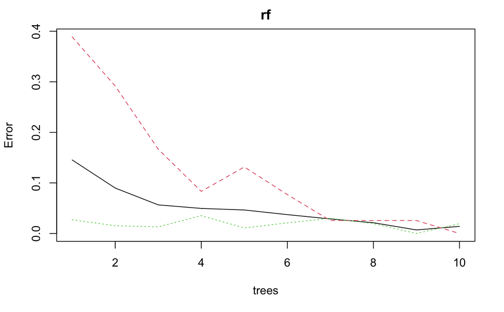

```r
plot(rf)
```

3. We can see clearly that using a random forest model over a single decision tree has decreased the error rate and thereby increased the accuracy.

Evaluating the model by running it on the test dataset :

```r
res<-predict(rf,newdata=test,type="class")
confusionMatrix(table(res,test$status))
```

```
Confusion Matrix and Statistics


res  0  1
  0 28  0
  1  0 43

               Accuracy : 1
                 95% CI : (0.9494, 1)
    No Information Rate : 0.6056
    P-Value [Acc > NIR] : 3.443e-16

                  Kappa : 1

 Mcnemar's Test P-Value : NA

            Sensitivity : 1.0000
            Specificity : 1.0000
         Pos Pred Value : 1.0000
         Neg Pred Value : 1.0000
             Prevalence : 0.3944
         Detection Rate : 0.3944
   Detection Prevalence : 0.3944
      Balanced Accuracy : 1.0000

       'Positive' Class : 0
```